# Test a Perceptual Phenomenon

[ Udacity Machine Learning Foundation Nanodegree- Course Project done by Pranali Naik]

# Project Overview:

In a Stroop task, participants are presented with a list of words, with each word displayed in a color of ink.The participant’s task is to say out loud the color of the ink in which the word is printed.

In each case, we measure the time it takes to name the ink colors in equally-sized lists. Each participant will go through and record a time from each condition.

Congruent words condition:- In this condition, Colour word Name is displayed in the same coloured ink as that of word name. for example RED is written RED ink as shown below.

Incongruent words condition:- In this condition, Colour word Name is not displayed in the same coloured ink as that of word name. for example RED is written in GREEN ink as shown below.

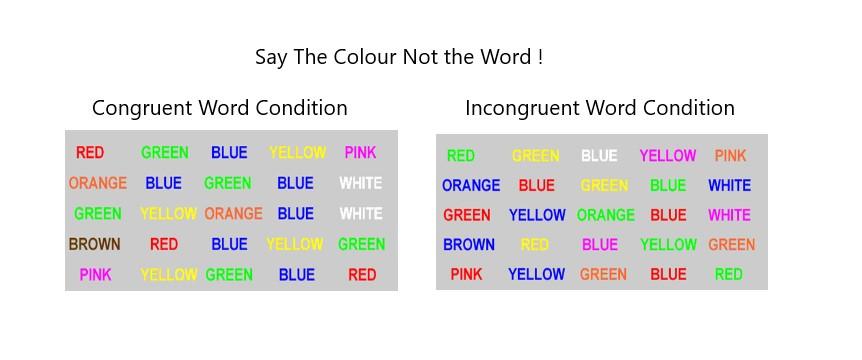

# Questions for Investigation

### Q1: What is our independent variable? What is our dependent variable?

Independent variable:- Congruent words and Incongruent words

Dependent variable:- Time taken to complete the naming of the colors in equally-sized lists of congruent and incongruent words .

### Q2: What is an appropriate set of hypotheses for this task? What kind of statistical test do you expect to perform? Justify your choices.

#### Null Hypothesis:

#### H0: μCongruent − μIncongruent = 0

It states that there are no differences between the response time for congruent words (Congruent) vs incongruent words (Incongruent). The mean difference between paired observations is zero.

where

μCongruent - the population mean of response time for congruent words.

μIncongruent - the population mean of response time for incongruent words.

#### Alternate Hypothesis:

#### HA: μCongruent − μIncongruent ≠ 0

It states that the difference between the response time for congruent words vs incongruent words is not zero.

#### Hypothesis Testing Justification:

The appropriate hypothesis choice will be the one which proves and validates the existence of the Stroop effect ; which suggest that the response time for naming the colour is less for congruent words than that of incongruent words. Hence, there must be a difference in the central tendencies of the population from which the sample is derived. Here, the question is - is this difference significant enough to be considered? Since, we cannot take into consideration the entire population, we need to work with the samples at hand and use the method of hypothesis and statistical testing to infer the results.

#### Proposed Test– Two tailed dependent sample T-test

#### Why the two tailed dependent sample T-test?

The selection of T-test is due to the fact that, we are comparing reaction time of a sample from same population in two different conditions (conguent & incongruent word conditions) and hence coming to a conclusion about the population.

If we get a significant result, we can reject the null hypothesis and accept the alternative hypothesis that there are statistically significant differences between the mean time taken to name ink color between two test conditions.

### Q3: Report some descriptive statistics regarding this dataset. Include at least one measure of central tendency and at least one measure of variability.

#### Import the required libraries

```python
# Import libraries
import pandas as pd
import numpy as np
import matplotlib.pyplot as plt
from scipy import stats
```

#### Creating dataframe

```python
#Creating dataframe
stroop_data = pd.read_csv('stroopdata.csv')
print(stroop_data.head())
```

```
   Congruent  Incongruent
0     12.079       19.278
1     16.791       18.741
2      9.564       21.214
3      8.630       15.687
4     14.669       22.803
```

#### Descriptive statistics calculation of data

```python
stroop_data_summary = stroop_data.describe()
print(stroop_data_summary)
```

```
       Congruent  Incongruent
count  24.000000    24.000000
mean   14.051125    22.015917
std     3.559358     4.797057
min     8.630000    15.687000
25%    11.895250    18.716750
50%    14.356500    21.017500
75%    16.200750    24.051500
max    22.328000    35.255000
```

```python
# Measures of Central Tendency and Variability
mean_congruent = stroop_data_summary['Congruent'].loc['mean']
mean_incongruent = stroop_data_summary['Incongruent'].loc['mean']
std_congruent = stroop_data_summary['Congruent'].loc['std']
std_incongreunt = stroop_data_summary['Incongruent'].loc['std']


print("\nMean Congruent reading times: {:.2f} s".format(mean_congruent))
print("\nMean Incongruent reading times: {:.2f} s".format(mean_incongruent))
print("\nStandard deviation of Congruent reading times: {:.2f} s".format(std_congruent))
print("\nStandard deviation of Incongruent reading times: {:.2f} s".format(std_incongreunt))
```

```
Mean Congruent reading times: 14.05 s

Mean Incongruent reading times: 22.02 s

Standard deviation of Congruent reading times: 3.56 s

Standard deviation of Incongruent reading times: 4.80 s
```

### Q4: Provide one or two visualizations that show the distribution of the sample data. Write one or two sentences noting what you observe about the plot or plots.

```
Text(0,0.5,'Reading times in seconds')
Text(0.5,0,'Word Coditions')
```

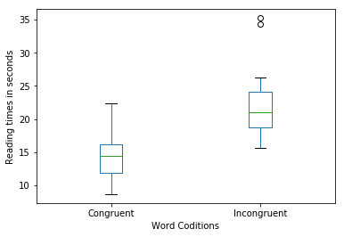

```
None
```

```python
#  Box Plot Visualization
stroop_data.plot.box()
print(plt.ylabel('Reading times in seconds'))
print(plt.xlabel('Word Coditions'))
print(plt.show())
```

As we can see from the plots itself that, congruent reading times overall are lesser than that of incongreunt reading times. Congruent reading times lower quartile and upper quartile range from roughly 12 to 16 seconds while incongruent reading times range from 18 to 24 seconds.

Further more as the calculated standard deviations shows, we can see that standard deviation of incongruent reading times is higher, as there are outliers.

### Q5: Now, perform the statistical test and report your results. What is your confidence level and your critical statistic value? Do you reject the null hypothesis or fail to reject it? Come to a conclusion in terms of the experiment task. Did the results match up with your expectations?

In order to test the hypotheses and perform T test, I have further calculated statistical data such as:

Mean and standard deviation of the difference between two conditions

Degree of freedom

T-Test i.e. t statistic value

t-critical value

p- value &

Confidence Interval

On the besis of above calculation i have rejected null hypothesis as shown below.please check.

```python
# Calculation of difference between both independant variable and its respective stats data

difference = stroop_data['Congruent'] - stroop_data['Incongruent']
difference_summary = difference.describe()
mean_difference = difference_summary.loc['mean']
std_difference = difference_summary.loc['std']

print("\nMean of the difference is {:.4f} s".format(mean_difference))
print("\nStandard deviation of the difference is {:.4f} s".format(std_difference))
```

```
Mean of the difference is -7.9648 s

Standard deviation of the difference is 4.8648 s
```

#### Degree of Freedom

Degree of freedom is the number of values which are free to vary without violating any given restriction.

Degree of freedom = n - 1

where, n = number of pairs in this case = 24

```python
# Degree of freedom Calculation (dfr)
n = 24
dfr = n-1
print("Degree of Freedom : {}".format(dfr))
```

```
Degree of Freedom : 23
```

#### Paired t test :

x¯D is the mean of difference between all the pairs and

sD is the sample standard deviation of the difference betweeen all the pairs.

μ0 is The constant μ0 in our case is 0, since H0:μCongruent − μIncongruent = 0

```python
# T test Calculation
sd = std_difference / np.sqrt(24)
t_stats = mean_difference / sd
print("\nt-statistic for the test is {:.4f}".format(t_stats))
```

```
t-statistic for the test is -8.0207
```

If the t-statistic lies outside the critical values of the t-distribution corresponding to our confidence level and degrees of freedom, we reject the null hypothesis.

#### t- critical value calculation

Significance level(α) is the criterion used for rejecting null hypothesis. Statisticians have commonly used either the 0.05 level (5% chance) or the 0.01 level (1% chance).

Confidence level is 1 - significance level.

Alternative hypothesis states HA : μCongruent − μIncongruent ≠ 0.

Since we hypothesized the possibility of relationship in both directions, we will use a two-tailed test to test our hypothesis. If we are using a significance level of 0.05, two-tailed t-test allocates 0.025 in each tail(shaded area). Both left and right shaded area are 2.5% of the total area under the curve.

A two-tailed test will test both, if μCongruent − μIncongruent is significantly greater than or less than μ0(0).

The μCongruent−μIncongruent is considered significantly different from μ0(0) if the test statistic is in the top 2.5% or bottom 2.5% of its probability distribution, resulting in a p-value less than 0.05.

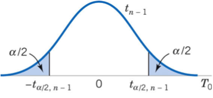

```python
# t- critical value calculation
t_critical = (stats.t.ppf(q=0.025, df= dfr), stats.t.ppf(q=0.975, df =dfr))
print("\nt_critical values at alpha = 0.05 for two-tailed T test:\n ({:.4f}, {:.4f}).".format(*t_critical))
```

```
t_critical values at alpha = 0.05 for two-tailed T test:
 (-2.0687, 2.0687).
```

So, here the t_statistic value (-8.0207) < t_crtical values (-2.0687) at alpha = 0.05

It means that the probability of finding t-statistic as extreme as ours is less than 5% if the null hypothesis was true. This probability is defined by the term p-value.

#### p value calculation:

P value is probability of null hypothesis given that the null hypothesis (H0) is true.

The lower the p-value the greater the confidence with which we can reject the null hypothesis.

```python
# P Value Calculation
pval = stats.t.cdf(t_stats, dfr)*2
print("P value is: {:.4e}".format(pval))
```

```
P value is: 4.1030e-08
```

So we should reject the null hypothesis.

#### Confidence Interval Calculation

Confidence intervals (CI) are a useful statistic to include because they indicate where the true population mean might be. It is common to report 95% confidence intervals.

[figure not shown]

```python
# Calculation of Confidence interval

ci = stats.norm.interval(0.95, loc = mean_difference, scale = sd)
print("Confidence Intervel : {}".format(ci))
```

```
Confidence Intervel : (-9.911092026449193, -6.01849130688414)
```

### Optional: What do you think is responsible for the effects observed? Can you think of an alternative or similar task that would result in a similar effect? Some research about the problem will be helpful for thinking about these two questions!

I think what is responsible for this effect is habit. If we go through this experiment continuously for 5 times. I have done this for fun and I have found that the time taken in both cases is less as well as difference is also decreased than that of doing the experiment for the first time.

"Reading a word" and "Saying out the ink in which the word is written" are two different activities for our brain. One which we do daily i.e Reading; but in general we never say or try to say the colour of ink in which the words are written.

So We become so good at it that brain automatically understands the meaning of words; whereas recognizing colors is not an “automatic process”.

When the brain has to read incongruent words it has to override its initial impulse of automatically reading the word so that it can recognize its color.

Also there is one more factor which i think is important and that is Focus or selective attention while doing this activity.

Another similar effect which has already been performed) and is an extension to the classic stroop test is the emotional stroop test. In emotional stroop test, the task is to name the colors of depressing words compared to normal words. In another type of stroop test, people suffering from a phobia are shown words related to phobia vs words not related to phobia and it has been found that they can name the colors of non-phobic words faster.